# Xác suất và phân bố xác suất

## Bài 6: Phân bố chuẩn

Một gia sư biết rằng khoảng thời gian cần thiết để hoàn thành một câu hỏi thống kê nhất định của sinh viên đại học năm thứ nhất, $X$, có phân bố chuẩn với giá trị trung bình là 17 phút và độ lệch chuẩn là 4.5 phút.

1. Xác suất một sinh viên được chọn ngẫu nhiên mất hơn 20 phút để hoàn thành câu hỏi là bao nhiêu?

```r
pnorm(20,17,4.5, lower.tail = FALSE)
```

```
## [1] 0.2524925
```

2. Xác suất một sinh viên mất từ 5 đến 10 phút để trả lời câu hỏi là bao nhiêu?

```r
pnorm(10,17,4.5) - pnorm(5,17,4.5)
```

```
## [1] 0.05607653
```

3. Cho biết $10\%$ sinh viên chậm nhất sẽ mất tối thiểu bao phút cho một câu hỏi?

```r
22.76
```

```
## [1] 22.76
```

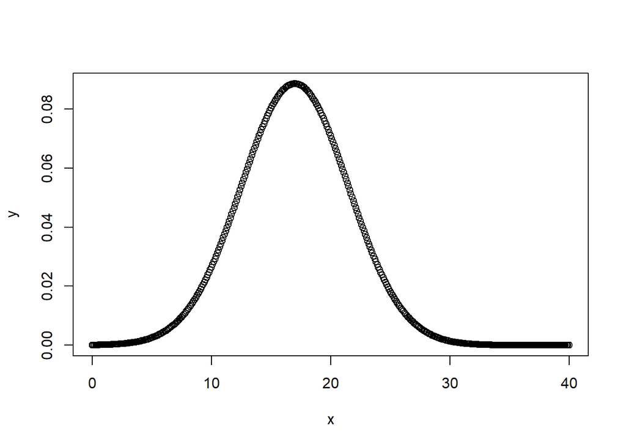

```r
x <- seq(0, 40, by = .1)
y <- dnorm(x, mean = 17, sd = 4.5)


plot(x,y)
```

e. Tạo ra thời gian hoàn thành câu hỏi cho 10 sinh viên từ phân bố đã cho.

```r
rnorm(10, 17, 4.5)
```

```
##  [1] 11.85230 10.77395 19.69801 13.25253 19.60791 14.78084 18.25746 28.09167
##  [9] 20.04675 21.95731
```

## Bài 7: Phân bố mũ

Giả sử một nhà sản xuất máy điều hòa rằng sản phẩm có tuổi thọ trung bình là 11 năm trước khi cần bất kỳ loại thông báo sửa chữa nào. Gọi biến ngẫu nhiên X đại diện cho thời gian máy hoạt động tốt cho đến khi cần sửa chữa và giả sử X tuân theo phân phối mũ với $\lambda_e = 1/11$.

1. Công ty cung cấp bảo hành sửa chữa toàn bộ trong vòng một năm cho thiết bị này. Xác suất để một chủ sở hữu của một máy điều hòa được chọn ngẫu nhiên sử dụng chế độ bảo hành là bao nhiêu?

```r
pexp(1, rate=1/11)
```

```
## [1] 0.08689928
```

2. Một công ty đối thủ cung cấp bảo hành 6 năm cho thiết bị điều hòa họ nhưng biết rằng các thiết bị của họ tồn tại trung bình chỉ chín năm trước khi yêu cầu một số loại sửa chữa. Cơ hội sử dụng bảo hành đó là bao nhiêu?

```r
pexp(6, rate=1/9)
```

```
## [1] 0.4865829
```

```r
1-pexp(15, rate=1/11)
```

```
## [1] 0.2557292
```